# GATA3 ChIP-seq analysis

Siyu Sun and Michael J. Guertin

2026-05-21

# 1 ChIP-seq experiments

ChIP-seq measures protein abundance on DNA and one can quantify protein modifications if an antibody to the modification is available. Controls are important. An IgG (or mock) IP is superior to input as a control.

# 2 ChIP-seq experiments design

MCF7 cells with the dTAG-GATA3 (clone522) grow in charcoal stripped medium (ER deprived) are treated under 3 conditions: 1) CC: null+null; 2) CE: null+ E2; 3) dE: dTAG+E2.  
Cells are ChIPed with IgG, CTCF, GATA3, ER, individually; plus an parallel-ChiP of CTCF and ER.

IgG ChIP is an control for background signals.

# 3 ChIP-seq data processing

## 3.1 Convert/Rename Data

**Converting data form**

```bash
# make sure there is a SampleSheet.csv in the *_AHVTG3BGXN directory
# cd 230922_NB551647_0109_AHTHMJBGXT
module load bcl2fastq
nohup bcl2fastq --runfolder-dir ./ --output-dir ./Data/Intensities/BaseCalls/ --no-lane-splitting
```

**Renaming file** We want to name the experiments with the trailing name being `PE1` or `PE2` for paired end data.

```bash
for i in *_S*R1_001.fastq.gz
do
    nm=$(echo $i | awk -F"/" '{print $NF}' | awk -F"_S" '{print $1}')
    echo $nm
      two=$(echo $i | awk -F"/" '{print $NF}' | awk -F"R1_001.fastq.gz" '{print $1}')
      mv $i ${nm}_PE1.fastq.gz
      mv ${two}R2_001.fastq.gz ${nm}_PE2.fastq.gz
done
```

## 3.2 check fastq file quality with `fastqc`

```bash
module load fastqc

for i in *fastq.gz
do
  echo $i
  fastqc $i
done
```

## 3.3 Cut off the adapter with `cutadapt`

In our daily workflow in the lab we use `cutadapt` to remove adapter sequences. The options we use below are:

- `-j` for the number of cores to use
- `-m` specifies the minimal length of a read to keep after adapter sequence removal
- `-O` is the number of bases to trim off the end of the read if it overlaps with the adapter sequence
- `-a` adapter sequence of PE1 reads
- `-A` adapter sequence of PE2 reads
- `-o` PE1 output file
- `-p` PE2 output file

If the genome contains 25% of each base, then one would expect a quarter of the reads that have no adapter to have the trailing base trimmed. Likewise, approximately 1/16 of the remaining reads without the adapter will have the final two bases trimmed. Technically these values are not exact, because the reads with matches to longer trailing k-mers (in this case 19-mers) would be removed first, then 18-mer matches removed, etc…

The `-a` and `-A` options are the adapter sequences of the PE1 and PE2 reads. The output file is `-o` (PE1) and `-p` PE2. The last two positional arguments are the input `fastq` files. We save the output to a log file.

```bash
module load cutadapt
for i in *PE1.fastq.gz
do
    name=$(echo $i | awk -F"/" '{print $NF}' | awk -F"_PE1" '{print $1}')
    echo $name
    echo unzipping $i
    gunzip $i
    echo unzipping ${name}_PE2.fastq.gz
    gunzip ${name}_PE2.fastq.gz
    cutadapt -a AGATCGGAAGAGCACACGTCTGAACTCCAGTCA -A AGATCGGAAGAGCGTCGTGTAGGGAAAGAGTGT -j 8 -m 10 -O 1 -o ${name}_PE1_no_adapt.fastq -p ${name}_PE2_no_adapt.fastq ${name}_PE1.fastq ${name}_PE2.fastq 2>&1 | tee ${name}_cutadapt.log
done
```

## 3.4 Align to the human genome

First we want to generate a folder in the convenient directory and name it as Genome. We will save all the genome files here. `cd` to this working directory, we are getting reference genome and chrom.sizes file from the USCS genome server, and build the genome index with `bowtie2-build`.

```bash
module load genometools/1.5.10
module load bowtie2
export PATH=$PATH:/home/FCAM/ssun/packages

wget https://hgdownload.cse.ucsc.edu/goldenpath/hg38/bigZips/hg38.fa.gz
gunzip hg38.fa.gz
bowtie2-build hg38.fa hg38

wget https://hgdownload-test.gi.ucsc.edu/goldenPath/hg38/bigZips/hg38.chrom.sizes
```

Now we are aligning the processed fastq files (no_adapt.fastq) to the `hg38.fa` genome. ChIP libraries are paired end. Note the `-1` and `-2` options for the respective paired-end `fastq` files. There is no need to save the output `sam` file, so the output is piped to `samtools` to convert to `bam`, then sorted by name (`-n`) so paired end reads are adjacent in the file.

The `bw.bam` files are piped to `samtools fixmate` which adds information about the fragment length by comparing the PE1 and PE2 coordinates, then the files are sorted by coordinate, then piped to `samtools markdup` to remove duplicate reads. Duplicate reads have the same PE1 and PE2 ends. This is very unlikely to happen by chance unless you sequence to very high read depth, so these reads are considered as PCR duplicates. The `fixmate` step is necessary to pipe to `markdup`.

We also run `seqOutBias` to generate the .bigWig files.

`samtools sort` sorts the output `hg38.bam` by name (`-n`) and generates `sorted.bam`. We will use these `sorted.bam` files to call peaks later.

We use the entire DNA fragment for making the browser tracks, which is accomplished by converted the paired-end `sorted.bam` file to a `bed12` and taking out discordant reads. We also normalize to read depth. We will upload these `normalized.bigWig` to trackhub for UCSC genome browser visualization.

```bash
#export PATH=$PATH:/home/FCAM/ssun/packages/

module load samtools/1.16.1
module load genometools/1.5.10
module load ucsc_genome/2012.05.22
module load rust
module load bowtie2
module load bedtools

export TMPDIR="${HOME}/temp"
sizes=/home/FCAM/ssun/Genome/hg38.chrom.sizes

genome=/home/FCAM/ssun/Genome/hg38.fa
genome_index=/home/FCAM/ssun/Genome/hg38_bt2/hg38
ncore=32
tallymer=hg38.tal_42.gtTxt.gz

for i in *hg38.bam
do
  name=$(echo $i | awk -F".hg38.bam" '{print $1}')
  echo $name
  seqOutBias ${genome} $i --shift-counts --no-scale \
                                      --bw=${name}.bigWig --read-size=42 --tallymer=$tallymer 2>&1 | tee ${name}_seqOutBias.log
done
```

- chip_alignment_230925.sh

```bash
hostname
name=230925

# I have seqOutBias and other packages export to my Path
export PATH=$PATH:/home/FCAM/ssun/packages/

module load samtools/1.16.1
module load genometools/1.5.10
module load ucsc_genome/2012.05.22
module load rust
module load bowtie2
module load bedtools

export TMPDIR="${HOME}/temp"
sizes=/home/FCAM/ssun/Genome/hg38.chrom.sizes

genome=/home/FCAM/ssun/Genome/hg38.fa
genome_index=/home/FCAM/ssun/Genome/hg38_bt2/hg38
ncore=32
tallymer=hg38.tal_42.gtTxt.gz

#gzip -d ${name}_PE1_no_adapt.fastq.gz
#gzip -d ${name}_PE2_no_adapt.fastq.gz
bowtie2 -p $ncore --maxins 800 -x $genome_index -1 ${name}_PE1_no_adapt.fastq -2 ${name}_PE2_no_adapt.fastq | samtools sort -@ $ncore -n -o ${name}.bw.bam
gzip ${name}_PE1_no_adapt.fastq
gzip ${name}_PE2_no_adapt.fastq
gzip ${name}_PE2.fastq
gzip ${name}_PE1.fastq
samtools fixmate -m ${name}.bw.bam - | samtools sort -@ $ncore - | samtools markdup -s -r - ${name}.hg38.bam
seqOutBias ${genome} ${name}.hg38.bam --shift-counts --no-scale \
                                      --bw=${name}.bigWig --read-size=42 --tallymer=$tallymer 2>&1 | tee ${name}_seqOutBias.log
samtools sort -@ $ncore -n -o ${name}.sorted.bam ${name}.hg38.bam
# the above samtools -n is sorting files by queryname, which is important for the next bedtools bamtobed command with the -bedpe flag;
# the bedtools bamtobed -bedpe is generating warning signs:
# *****WARNING: Query {...} is marked as paired, but its mate does not occur next to it in your BAM file.  Skipping.
# This might due to some single end sequences, I checked the fraction of these not paired sequences, it is <1.5%, so we don't need to worry.
bedtools bamtobed -i ${name}.sorted.bam -bedpe > ${name}_bed12.bed

awk '$1==$4 {print $0}' ${name}_bed12.bed | awk '{OFS="\t";} {print $1, $2, $6}' | awk '$1!="." && $3>$2 && (($3 - $2)<2000) {print $0}' | sort -k1,1 -k2,2n > ${name}_read_span.bed
genomeCoverageBed -bg -i ${name}_read_span.bed -g $sizes > ${name}.bedGraph
depth=`awk -F'\t' '{sum+=$5;}END{print sum;}' ${name}.hg38_not_scaled.bed`
echo "depth is " $depth
scaled=$(bc <<< "scale=3 ; 10000000 / $depth")
echo "scale is " $scaled
awk -v scaled="$scaled" '{OFS="\t";} {print $1, $2, $3, $4*scaled}' ${name}.bedGraph > ${name}_normalized.bedGraph
wigToBigWig -clip ${name}_normalized.bedGraph $sizes ${name}_normalized.bigWig
echo "complete"
```

**Run the previous chunk in parallel**

Now we are generating tallymer files and table use `seqOutBias` outside the loop, and then run the previous chunk in parallel.  
We need to know the read size of our library. Here the read size is 42.

```bash
#Compute mappability for the given read length and the k-mer that corresponds to each possible read alignment position
#time-consuming but only need to run this one time
seqOutBias seqtable hg38.fa --read-size=42
mkdir -p ${HOME}/temp

file=chip_alignment_230925.sh

for i in *_PE1_final.fastq
do
    nm=$(echo $i | awk -F"/" '{print $NF}' | awk -F"_PE1_final.fastq" '{print $1}')
    echo $nm
    sed -e "s/230925/${nm}/g" "$file" > pro_processing_${nm}.sh
    sbatch pro_processing_${nm}.sh
    sleep 1
done
```

## 3.5 Alignment rate and post-alignment read depth

**Alignment rate**

```bash
for i in *chip_alignment*.err
do
  name=$(echo $i | awk -F".sh" '{print $1}')
  echo $name
  alignrate=$(cat $i | grep "overall alignment rate")
  echo $alignrate
done 2>&1 | tee alignment_rate.txt
```

**Aligned reads** bowtie2 direct output:

```bash
module load samtools/1.16.1
for i in *bw.bam
do
  echo $i
  samtools view -c -f 0x42 $i
done 2>&1 | tee -a aligned_reads_from_bam_log.txt

module load R/4.1.2
R
library("lattice")
df_sum=read.table('aligned_reads_from_bam_log.txt', sep = "", header=FALSE)

df_plot=data.frame(file=df_sum[seq(1, nrow(df_sum), by=2),],
                   reads=as.numeric(df_sum[seq(2, nrow(df_sum), by=2),]))

pdf('barplot_GATA3_ChIP_Pool2_1_reads.pdf',width=8,height=8)
print(barchart(reads~ file,
         data = df_plot,
         auto.key=list(space="right"),
         scales = list(x = list(rot = 45)),
         ylab = "libraries",
         xlab = "post-alignment reads",
         col="light blue",
         panel=function(...) {
           panel.barchart(...)
           panel.abline(h=15000000, lty = "dotted", col = "red", identifier = "abline")
       })
)
dev.off()
```

de-duplicate, sorted output:

```bash
module load samtools/1.16.1
for i in *sorted.bam
do
  echo $i
  samtools view -c -f 0x42 $i
done 2>&1 | tee -a aligned_reads_from_sorted_bam_log.txt
```

# 4 Genome Browser

Usually we combine replicates into a single track for visualization and we compare the tracks between conditions. It is important that we **read-depth normalize** (we are currently trying to change from read-depth normalize to deseq2 size-factor normalize) before we combine the signal from each replicate. Otherwise, we would be weighting replicates differently; for example, if a library is sequenced to twice the read depth and we combine first then read depth normalize, then the more high coverage data is weighted twice as much in the final visualization. All the relevant track files are here:

**Single library (normalized)**

UCSC Genome Browser trackhub link for non-merged, normalized bigWig files: http://guertinlab.cam.uchc.edu/GATA3_ChIP_nonmerge_hub/hub.txt

# 5 Peak calling

## 5.1 calling GATA peaks with `Macs3`

We want to call a set of universal peaks for the same ChIP factors. The reasons are: taking intersection of peaks between replicates/conditions will result in high false negative rates. We may lose important binding regions for transcription factor analysis. Here we are doing a compromise to call every peaks on all files and later in downstream analysis we will decide the functional peaks.

We use `Macs3 callpeaks` to identify TF binding sites. It takes the treatment files against the control genomic input.  
`-t/--treatment FILENAME` takes your treatment file. If there is more than one alignment file, we can specify them as `-t A B C`. MACS will pool up all these files together.  
`-c/--control` takes the control file. Here we pool all the IgG file.  
`-n/--name` is the output name we give.  
`-f/--format FORMAT` we specify BAMPE format for the output.  
`-g/--gsize` is the mappable genome size or effective genome size. The actual mappable genome size is ~70% to 90% of the genome size due to the repetitive features on the chromosomes. Here we use the default hs –2.7e9 (for human genome).  
`-q/--qvalue` is the FDR cutoff to call signidicant regions.

**GATA peaks**

```bash
#! /bin/sh
#SBATCH --job-name=GATA_chip_peak_calling.sh
#SBATCH -N 1
#SBATCH -n 1
#SBATCH -c 2
#SBATCH -p amd
#SBATCH --qos=general
#SBATCH --mem=32G
#SBATCH --mail-type=ALL
#SBATCH --mail-user=ssun@uchc.edu
#SBATCH -o chip_peak_calling.sh_%j.out
#SBATCH -e chip_peak_calling.sh_%j.err

hostname
module load macs3

mkdir temp_macs
directory=/home/FCAM/ssun/GATA3_ChIP_PRO_July2023/ChIP_final/sorted.bam_final/
# GATA_CC against IgG
macs3 callpeak --call-summits -t ${directory}*_GATA_CC*sorted.bam -c ${directory}*IgG*sorted.bam -n GATA_ChIP -g hs -q 0.01 --keep-dup all -f BAMPE --nomodel --tempdir temp_macs

#wc -l GATA_ChIP_summits.bed
#99289
```

**CTCF peaks**

```bash
#! /bin/sh
#SBATCH --job-name=CTCF_chip_peak_calling.sh
#SBATCH -N 1
#SBATCH -n 1
#SBATCH -c 32
#SBATCH -p general
#SBATCH --qos=general
#SBATCH --mem=68G
#SBATCH --mail-type=ALL
#SBATCH --mail-user=ssun@uchc.edu
#SBATCH -o CTCFchip_peak_calling.sh_%j.out
#SBATCH -e CTCFchip_peak_calling.sh_%j.err

hostname
module load macs3

mkdir temp_macs
directory=/home/FCAM/ssun/GATA3_ChIP_PRO_July2023/ChIP_final/sorted.bam_final/
# CTCF_CC against IgG
macs3 callpeak --call-summits -t ${directory}*_CTCF_CC*sorted.bam -c ${directory}*IgG*sorted.bam -n CTCF_ChIP -g hs -q 0.01 --keep-dup all -f BAMPE --nomodel --tempdir temp_macs
```

```bash
#! /bin/sh
#SBATCH --job-name=remove_peak.sh
#SBATCH -N 1
#SBATCH -n 1
#SBATCH -c 32
#SBATCH -p general
#SBATCH --qos=general
#SBATCH --mem=32G
#SBATCH --mail-type=ALL
#SBATCH --mail-user=ssun@uchc.edu
#SBATCH -o remove_peak.sh_%j.out
#SBATCH -e remove_peak.sh_%j.err
module load deeptools/3.5.0
module load bedtools
wget https://github.com/Boyle-Lab/Blacklist/raw/master/lists/hg38-blacklist.v2.bed.gz
gunzip hg38-blacklist.v2.bed.gz
blacklist=hg38-blacklist.v2.bed
sizes=/home/FCAM/ssun/Genome/hg38.chrom.sizes


for i in *_summits.bed
do
    name=$(echo $i | awk -F"/" '{print $NF}' | awk -F"_summits.bed" '{print $1}')
    echo $name
    grep -v "random" ${name}_summits.bed | grep -v "chrUn" | grep -v "chrEBV" | grep -v "chrM" | grep -v "alt" | intersectBed -v -a - -b $blacklist > ${name}_summits_final.bed
    slopBed -b 50 -i ${name}_summits_final.bed -g $sizes  | sort -k1,1 -k2,2n > ${name}_summit_100window.bed
  slopBed -b 200 -i ${name}_summits_final.bed -g $sizes  | sort -k1,1 -k2,2n > ${name}_summit_400window.bed
done

#wc -l CTCF_ChIP_summit_100window.bed
#94738
```

## 5.2 Removing peaks on contigs and within blacklisted regions

Google “blacklisted genomic regions” we can find a set of region in the genome in `bed` format that have an over-representation of reads regardless of the experiment. We also remove peaks on non-canonical chromosomes with `grep -v`.

All intervals in the summits file span one base, and we use `bedtools slop` to change boundaries by adding a fixed number of bases in each direction (`-b`). These 101 base intervals will be used as input for de novo motif analysis. The 401 base intervals will be used to calculate peak intensity. The rationale for a smaller window for motif analysis is the following:  
1) the motif is typically very close to the peak summit,  
2) larger window increases the computation time substantially, and  
3) the flanking sequence is less enriched for the relevant motifs and de novo motif analysis is less sensitive with higher noise relative to background.

We use a standard window size to calculate peak intensity, but we use a much wider window because signal 200 bases up or downstream can result from signal. We could increase the window to 600 bases and that would be fine as well. You can vary this window systematically and determine if varying the window affects the relative peak intensity rank. We use the same window size for each peak because otherwise wider windows (note the narrowPeaks file outputs are variable width) would inherently have more reads.

```bash
module load deeptools/3.5.0
module load bedtools
wget https://github.com/Boyle-Lab/Blacklist/raw/master/lists/hg38-blacklist.v2.bed.gz
gunzip hg38-blacklist.v2.bed.gz
blacklist=hg38-blacklist.v2.bed
sizes=/home/FCAM/ssun/Genome/hg38.chrom.sizes


for i in *_summits.bed
do
    name=$(echo $i | awk -F"/" '{print $NF}' | awk -F"_summits.bed" '{print $1}')
    echo $name
    grep -v "random" ${name}_summits.bed | grep -v "chrUn" | grep -v "chrEBV" | grep -v "chrM" | grep -v "alt" | intersectBed -v -a - -b $blacklist > ${name}_summits_final.bed
    slopBed -b 50 -i ${name}_summits_final.bed -g $sizes  | sort -k1,1 -k2,2n > ${name}_summit_100window.bed
  slopBed -b 200 -i ${name}_summits_final.bed -g $sizes  | sort -k1,1 -k2,2n > ${name}_summit_400window.bed
done
```

**peak numbers**

```bash
wc -l GATA_ChIP_summits_final.bed #96868
```

# 6 FRiP

FRiP (Fraction of Reads in Peaks), is a common quality measurement for ChIP-seq experiment. It calculates the percentage of all reads that fall in peak regions mapped to the genome. It is important that we always use a universal peak set to calculate the FRiP score for each replicates, then compare between replicates. Usually, we will use the peak set that we generated previously from MACS3, since in that step we have called peaks using all replicates in bam format for the same ChIP factor.

## 6.1 FRiP for GATA

```r
module load bedtools
module load samtools/1.12
peaks=/home/FCAM/ssun/GATA3_ChIP_PRO_July2023/ChIP_final/peak_call/GATA_ChIP_summit_400window.bed

for i in /home/FCAM/ssun/GATA3_ChIP_PRO_July2023/ChIP_final/FRiP/not_scaled_bed/*_not_scaled.bed
do
    nm=$(echo $i | awk -F"/" '{print $NF}' | awk -F"_not_scaled.bed" '{print $1}')
    sort -k1,1 -k2,2n $i > ${nm}_sorted.bed
    mapBed -null '0' -a $peaks -b ${nm}_sorted.bed > ${nm}_peak_counts.txt
done

for i in *_peak_counts.txt
do
    name=$(echo $i | awk -F"/" '{print $NF}' | awk -F".hg38_peak_counts.txt" '{print $1}')
    echo $name > ${name}_FRiP.txt
    awk '{print $NF}' ${name}.hg38_peak_counts.txt > ${name}_peak_counts_only.txt
    RiP=$(awk '{sum+=$1;} END{print sum;}' ${name}_peak_counts_only.txt) # count the reads in each peak region (from the universal set)
    echo $name | cat - ${name}_peak_counts_only.txt > ${name}_peak_counts.txt
    aligned_reads=$(samtools view -c -f 0x42  /home/FCAM/ssun/GATA3_ChIP_PRO_July2023/ChIP_final/sorted.bam_final/${name}.sorted.bam) # count the total aligned reads
    FRiP=$(echo "scale=2 ; $RiP / $aligned_reads" | bc)
    echo $FRiP >> ${name}_FRiP.txt
    rm ${name}_peak_counts_only.txt
done

echo -e "chr\tstart\tend\tname\tqvalue" | cat - $peaks | paste -d'\t' - *peak_counts.txt > Combined_GATA_peak_counts.txt
echo -e "Name" > rowname.txt
echo -e "FrIP" >> rowname.txt
paste -d'\t' rowname.txt *FRiP.txt > Combined_GATA_FRiP.txt
rm rowname.txt
```

```r
library(lattice)
frip.df=read.csv("GATA_peak_FRiP.csv")
frip.df$supp=factor(frip.df$supp, levels=c("GATA","CTCF","IgG","ER", "CTER"))
pdf('barplot_GATA3_peak_FRiP.pdf',width=8,height=8)
print(barchart(library~FRiP,
         group=supp,
         stack=T,
         data = frip.df,
         #auto.key=list(space="right"),
         #scales = list(x = list(rot = 45)),
         ylab = "libraries",
         xlab = "GATA3 peak FRiP score",
         main ="MCF7 GATA3 ChIP peak FRiP",
         par.settings = list(superpose.polygon=list(col=c("#FF9999","palegoldenrod", "white","white","white"), border="grey")))
         #col=rep(c(rep("light blue",3),rep("#00AAFF",3), rep("#FF9999",4)),3))
)
dev.off()
```

# 7 Peak Intensity

There are two things we need to consider regarding peak intensities. The first is peak region; the second is dynamic range. Imaging a peak that is very intense but within a narrow range, the other peak is not so intense but can span its signals across a very long distance. We need to consider this region differences while calling any peak to be intense or not.  
## Counting reads in peaks (400bp window)

**with `mapBed`**  
We will first use the `mapBed` subcommand from `bedtools` to count the BED file from the seqOutBias output in the 400 base window peak summits file.

The `mapBed` map overlapping features in a B file onto features in an A file and apply statistics to the features.  
By default, map computes the sum of the 5th column (the score field for BED format) for all intervals in B that overlap each interval in A.  
`-null` The value to print if no overlaps are found for an A interval.  
refer to: https://bedtools.readthedocs.io/en/latest/content/tools/map.html

```r
#mkdir GATA_mapbed
#cd GATA_mapbed
module load bedtools

sort -k1,1 -k2,2n /home/FCAM/ssun/GATA3_ChIP_PRO_July2023/ChIP_final/peak_call/GATA_ChIP_summit_400window.bed > GATA_ChIP_summit_400window_sorted.bed
summitWin=GATA_ChIP_summit_400window_sorted.bed
for i in /home/FCAM/ssun/GATA3_ChIP_PRO_July2023/ChIP_final/hg38_not_scaled_bed/*GATA_CC*_not_scaled.bed
do
    nm=$(echo $i | awk -F"/" '{print $NF}' | awk -F"_not_scaled.bed" '{print $1}')
    sort -k1,1 -k2,2n $i > ${nm}_sorted.bed
    #mapBed -null '0' -a $summitWin -b ${nm}_sorted.bed > GATA_ChIP_summit_counts.bed
    mapBed -null '0' -a $summitWin -b ${nm}_sorted.bed > ${nm}_summit_counts.bed
done
#MCF7_dTAGGATA522_GATA_CC_rep1.hg38_summit_counts.bed
#MCF7_dTAGGATA522_GATA_CC_rep2.hg38_summit_counts.bed
#MCF7_dTAGGATA522_GATA_CC_rep3.hg38_summit_counts.bed
```

R and parse quantile

```r
module load R/4.1.2
R
#libraries
library(DESeq2)
library(lattice)
library(dplyr)
library(ggplot2)
library(limma)
library(bigWig)

peak.intensities1 = read.table('MCF7_dTAGGATA522_GATA_CC_rep1.hg38_summit_counts.bed', header =FALSE)
peak.intensities2 = read.table('MCF7_dTAGGATA522_GATA_CC_rep2.hg38_summit_counts.bed', header =FALSE)
peak.intensities3 = read.table('MCF7_dTAGGATA522_GATA_CC_rep3.hg38_summit_counts.bed', header =FALSE)

peak.intensities=cbind(peak.intensities1, peak.intensities2, peak.intensities3)[,c(1:6,12,18)]
peak.intensities$mean = rowMeans(peak.intensities[,6:8])

#peak.intensities = read.table('GATA_ChIP_summit_counts.bed', header =FALSE)

quantile(peak.intensities$mean, probs = seq(.05, 1.00, by = .05))

# 5%        10%        15%        20%        25%        30%        35%
#  13.33333   15.66667   17.33333   18.66667   20.00000   21.33333   23.00000
#       40%        45%        50%        55%        60%        65%        70%
#  25.00000   27.00000   29.00000   32.00000   35.33333   40.00000   46.00000
#       75%        80%        85%        90%        95%       100%
#  54.66667   66.66667   85.66667  118.66667  186.00000 8498.66667


chr = peak.intensities$V1
start = as.numeric(peak.intensities$V2)+200
end = as.numeric(peak.intensities$V3)-200
mean =peak.intensities$mean
peak.intensities.final=data.frame(chr, start, end, mean)

j =0
q=seq(.05, 1.00, by = .05)
count=0
for (i in quantile(peak.intensities.final$mean, probs = seq(.05, 1.00, by =
.05)))
{
count = count +1

#generate a 1bp ChIP summit file parsed into 20 intensity quantiles.
write.table(file = paste0('quantile', as.character(q[count]), '.bed'), peak.intensities.final[peak.intensities.final$mean > j & peak.intensities.final$mean <= i,], sep = '\t', quote=FALSE, col.names=FALSE, row.names=FALSE )
j = i
}
save.image('231004_GATA3_ChIP_mapbed.Rdata')
```

**with `DeSeq2`**

```r
# mkdir GATA_Deseq2
# cd GATA_Deseq2/

# calculate the size factors
module load samtools/1.12

dir=/home/FCAM/ssun/GATA3_ChIP_PRO_July2023/ChIP_final/sorted.bam_final/
for i in GATA
do
  echo $i
  > ${i}_header.txt
  > ${i}_reads.txt
  for j in ${dir}MCF7_dTAGGATA522*_${i}_*.sorted.bam
  do
    echo $j
    name=$(echo $j | awk -F $dir '{print $2}' | awk -F".sorted.bam" '{print $1}')
    echo $name | paste ${i}_header.txt - > ${i}_tmp.txt
    mv ${i}_tmp.txt ${i}_header.txt
    reads=`samtools view -c -f 0x3 $j` #reads paired and mapped in proper pair
    echo $reads | paste ${i}_reads.txt - > ${i}_tmp.txt
    mv ${i}_tmp.txt ${i}_reads.txt
  done
  cat ${i}_header.txt ${i}_reads.txt > ${i}_tmp.txt
  mv ${i}_tmp.txt ${i}_reads.txt
  rm ${i}_header.txt
done
```

R; load packages

```r
mkdir GATA_deseq
cd GATA_deseq
module load R/4.1.2 # this version of `R` on Xanadu has many of our libraries pre-installed.
R

#libraries
library(DESeq2)
library(lattice)
library(dplyr)
library(ggplot2)
library(limma)
library(bigWig)

#functions on github
source('https://raw.githubusercontent.com/mjg54/znf143_pro_seq_analysis/master/docs/ZNF143_functions.R')

#new functions
get.counts.interval <- function(df, path.to.bigWig, file.prefix = 'H') {
    vec.names = c()
    inten.df=data.frame(matrix(ncol = 0, nrow = nrow(df)))

    for (mod.bigWig in Sys.glob(file.path(path.to.bigWig, paste(file.prefix, "*.bigWig", sep ='')))) {
        factor.name = strsplit(strsplit(mod.bigWig, "/")[[1]][length(strsplit(mod.bigWig, "/")[[1]])], '.bigWig')[[1]][1]
        print(factor.name)
        vec.names = c(vec.names, factor.name)
        loaded.bw = load.bigWig(mod.bigWig)
        print(mod.bigWig)
        mod.inten = bed.region.bpQuery.bigWig(loaded.bw, df, abs.value = TRUE)
        inten.df = cbind(inten.df, mod.inten)
    }
    colnames(inten.df) = vec.names
    r.names = paste(df[,1], ':', df[,2], '-', df[,3], sep='')
    row.names(inten.df) = r.names
    return(inten.df)
}
```

DeSeq count read size and parse into different quantile

```r
# recall that these summit_XXXwindow.bed has the peak region info.
a =  read.table('/home/FCAM/ssun/GATA3_ChIP_PRO_July2023/ChIP_final/peak_call/GATA_ChIP_summit_400window.bed', sep = "\t", header=FALSE)
#normalized signal
#GATA.signal.df= get.counts.interval(a, "/home/FCAM/ssun/GATA3_ChIP_PRO_July2023/ChIP_final/bigWigs/normalized_bw","MCF")
#non-normalized counts
GATA.counts.df= get.counts.interval(a, "/home/FCAM/ssun/GATA3_ChIP_PRO_July2023/ChIP_final/bigWigs/Seqoutbias_bw","MCF")
GATA.analysis.regions=GATA.counts.df[,grepl("_GATA_",colnames(GATA.counts.df))] # non-normalized counts
# identical(rownames(GATA.analysis.regions),rownames(GATA.counts.df))
# [1] TRUE

sample.conditions = factor(sapply(strsplit(colnames(GATA.analysis.regions), '_rep'), '[', 1))
deseq.counts.table = DESeqDataSetFromMatrix(countData = GATA.analysis.regions, # DESeqDataSet needs countData to be non-negative integers; non-normalized counts are integer, normalized signals has decimals.
                colData = as.data.frame(sample.conditions),
                design = ~ sample.conditions)


GATA.SF <- read.table("GATA_reads.txt", sep = '\t', header = TRUE)[,-1] # GATA size factors from read depth
GATA.size.factors = estimateSizeFactorsForMatrix(GATA.SF) # size factor transformed to smaller ratios
#MCF7_dTAGGATA522_GATA_CC_rep1 0.5385594
#MCF7_dTAGGATA522_GATA_CC_rep2 0.5169334
#MCF7_dTAGGATA522_GATA_CC_rep3 0.5469193
#MCF7_dTAGGATA522_GATA_CE_rep1 0.8108480
#MCF7_dTAGGATA522_GATA_CE_rep2 2.3452478
#MCF7_dTAGGATA522_GATA_CE_rep3 2.1708044

sizeFactors(deseq.counts.table) <- GATA.size.factors
# assign to each column of the count matrix (deseq.counts.table) the size factor to bring each column to a common scale
dds <- DESeq(deseq.counts.table)

normalized.counts.GATA3 = counts(dds, normalized=TRUE)
peak.intensities = rowMeans(normalized.counts.GATA3[,1:3]) # we want to get the average read counts for CC groups

names(peak.intensities) = rownames(normalized.counts.GATA3)
chr = sapply(strsplit(names(peak.intensities), ":"), "[", 1)
rnge = sapply(strsplit(names(peak.intensities), ":"), "[", 2)
start = as.numeric(sapply(strsplit(rnge, "-"), "[", 1)) + 200
end = as.numeric(sapply(strsplit(rnge, "-"), "[", 2)) - 200

quantile(peak.intensities, probs = seq(.05, 1.00, by = .05))
#         5%         10%         15%         20%         25%         30%
#   25.03477    29.26822    32.24003    34.85009    37.44833    40.19495
#        35%         40%         45%         50%         55%         60%
#   43.16713    46.62380    50.27567    54.50266    59.81136    66.40026
#        65%         70%         75%         80%         85%         90%
#   74.63208    86.00656   102.11487   125.08599   160.58147   222.03676
#        95%        100%
#  348.55000 15936.61845

# 1bp summit all GATA3 peaks
peak=data.frame(chr, start, end, peak.intensities)
head(peak)
#                    chr  start    end peak.intensities
#chr1:827180-827581 chr1 827380 827381         45.32469
#chr1:845596-845997 chr1 845796 845797        530.34196
#chr1:869297-869698 chr1 869497 869498         18.62632
#chr1:916569-916970 chr1 916769 916770         36.69993
#chr1:917334-917735 chr1 917534 917535        124.64502
#chr1:924653-925054 chr1 924853 924854         30.44684
nrow(peak)
#[1] 96868
ranked_peak <- peak[order(-peak[, 4]), ]
write.table(ranked_peak, file = 'GATA_ChIP_summits_final_DESeq2_ranked_intensity.bed', sep = '\t', quote=FALSE, col.names=FALSE, row.names=FALSE )


# 1bp summit quantile file
j =0
q=seq(.05, 1.00, by = .05)
count=0
for (i in quantile(peak.intensities, probs = seq(.05, 1.00, by =
.05)))
{
count = count +1

write.table(file = paste0('quantile', as.character(q[count]), '_summits.bed'), data.frame(chr[peak.intensities > j & peak.intensities <= i], start[peak.intensities > j & peak.intensities <= i], end[peak.intensities > j & peak.intensities <= i], peak.intensities[peak.intensities > j & peak.intensities <= i]), sep = '\t', quote=FALSE, col.names=FALSE, row.names=FALSE )
j = i
}

# making 100 window quantile file
start1 = as.numeric(sapply(strsplit(rnge, "-"), "[", 1)) + 150
end1 = as.numeric(sapply(strsplit(rnge, "-"), "[", 2)) - 150
j =0
q=seq(.05, 1.00, by = .05)
count=0
for (i in quantile(peak.intensities, probs = seq(.05, 1.00, by =
.05)))
{
count = count +1

write.table(file = paste0('quantile', as.character(q[count]), '_summits_100window.bed'), data.frame(chr[peak.intensities > j & peak.intensities <= i], start1[peak.intensities > j & peak.intensities <= i], end1[peak.intensities > j & peak.intensities <= i], peak.intensities[peak.intensities > j & peak.intensities <= i]), sep = '\t', quote=FALSE, col.names=FALSE, row.names=FALSE )
j = i
}

save.image('231004_GATA3_ChIP_deseq.Rdata')
```

Now we have a ChIP-seq peak summits file that are properly ranked by its intensity calculated from 400window Deseq2.  
“GATA_ChIP_summits_final_DESeq2_ranked_intensity.bed”

## 7.1 dynamic range

**`mapbed` Peak Intensity in 20 Quantiles (log10)**

```r
# cd GATA_Deseq2
# module load R/4.1.2
# R
# load('231004_GATA3_ChIP_mapbed.Rdata')
library(lattice)

j =0
q=seq(.05, 1.00, by = .05)
count=0
df.dr = data.frame(matrix(nrow = 0, ncol = 5))
for (i in quantile(peak.intensities.final$mean, probs = seq(.05, 1.00, by =
.05)))
{
count = count +1

temp=peak.intensities.final[peak.intensities.final$mean > j & peak.intensities.final$mean <= i,]
temp$quantile=paste0('quantile', as.character(q[count]))
df.dr=rbind(df.dr, temp)
j = i
}

df.dr$log10mean=log10(df.dr$mean)

pdf('ChIP dynamic range (log10 average intensity) bw plot (mapbed).pdf', width=8,height=5)
print(bwplot(log10mean ~ quantile,#do.out = FALSE,
             data = df.dr,
             ylim=c(0,4),
             auto.key=list(space="top", columns=2),
             scales = list(x = list(rot = 45)),
             pch="|",
             col="black",
             cex=0.5,
             panel=function(...) {
                                  panel.bwplot(...)
                                  panel.abline(h=2.438, lty = "dotted", col = "red", identifier = "abline")
                                  panel.abline(h=1.438, lty = "dotted", col = "red", identifier = "abline")
                                  }
             ))
dev.off()

# for the quantile1(log10 intensity)
#   Min. 1st Qu.  Median    Mean 3rd Qu.    Max.
#  2.270   2.344   2.438   2.486   2.575   3.929

# a 10 fold difference (in median) is cut at quantile 0.5
```

**`deseq2` Peak Intensity in 20 Quantiles (log10)**

```r
# cd GATA_Deseq2
# module load R/4.1.2
# R
# load('231004_GATA3_ChIP_deseq.Rdata')
library(lattice)

j =0
q=seq(.05, 1.00, by = .05)
count=0
df.dr = data.frame(matrix(nrow = 0, ncol = 5))

for (i in quantile(peak.intensities, probs = seq(.05, 1.00, by =.05)))
{
count = count +1

temp=data.frame(chr[peak.intensities > j & peak.intensities <= i], start[peak.intensities > j & peak.intensities <= i], end[peak.intensities > j & peak.intensities <= i], peak.intensities[peak.intensities > j & peak.intensities <= i])
temp$quantile=paste0('quantile', as.character(q[count]))
df.dr=rbind(df.dr, temp)
j = i
}
colnames(df.dr)=c("chr","start","end", "intensity", "quantile")
df.dr$log10mean=log10(df.dr$mean)

pdf('ChIP dynamic range  (log10 average intensity) bw plot (deseq2).pdf', width=8,height=5)
print(bwplot(log10mean ~ quantile,do.out = FALSE,
             data = df.dr,
             ylim=c(0,4),
             auto.key=list(space="top", columns=2),
             scales = list(x = list(rot = 45)),
             pch="|",
             col="black",
             cex=0.5,
             panel=function(...) {
                                  panel.bwplot(...)
                                  panel.abline(h=2.710, lty = "dotted", col = "red", identifier = "abline")
                                  panel.abline(h=1.710, lty = "dotted", col = "red", identifier = "abline")
                                  }
             ))
dev.off()

# for the quantile1
#   Min. 1st Qu.  Median    Mean 3rd Qu.    Max.
#  2.542   2.616   2.710   2.759   2.848   4.202
```

# 8 De novo motif analysis

## 8.1 (Quick check) Top enriched motif within peak set

De novo motif analysis uses tools like `MEME`, `TOMTOM`, `MAST` and `FIMO` to analyze binding site. The `MEME` analysis suite allows users to indentify (de novo) enriched motifs with a set of sequences, and compare to databases of known motifs; it also allow users to search for motifs of interest within a set of sequences… The user manual and more usage can be found here：https://meme-suite.org/meme/doc/meme.html

In this analysis, we will first convert the coordinate bed file to a sequence fasta file, then we perform de novo motif analysis with `meme`. Here we only want to do a quick quality check by manually looking at the top hit to ensure that it is a GATA motif variant for GATA peaks.

**GATA peaks**

```bash
module load deeptools/3.5.0
module load meme/5.4.1
module load bedtools
genome=/home/FCAM/ssun/Genome/hg38.fa
sizes=/home/FCAM/ssun/Genome/hg38.chrom.sizes
dir=/home/FCAM/ssun/GATA3_ChIP_PRO_July2023/ChIP_final/peak_call/

#GATA_ChIP_summit_100window.bed
name=GATA_ChIP

# Just did the top 2000 GATA peaks to make it faster
sort -nrk5,5 ${dir}${name}_summit_100window.bed | head -n 2000 > ${name}_top2000_summit_100window.bed
name=${name}_top2000
fastaFromBed -fi $genome -bed ${name}_summit_100window.bed -fo ${name}_summit_100window.fasta
# MEME
meme -p 32 -oc ${name}_meme_test -nmotifs 1 -objfun classic -csites 20000 -searchsize 0 -minw 5 -maxw 15 -revcomp -dna -markov_order 3 -maxsize 100000000 ${name}_summit_100window.fasta # normal GATA motif is GATAA, so minw can be set to 5
```

By searching the top 2000 most significant GATA peaks, we find the top motif match to the GATA3.

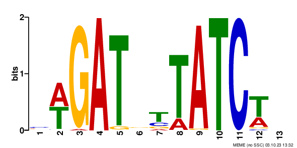

Figure 1: First de novo identified motif matched to the GATA3 motif

**CTCF peaks**

```bash
module load deeptools/3.5.0
module load meme/5.4.1
module load bedtools
genome=/home/FCAM/ssun/Genome/hg38.fa
sizes=/home/FCAM/ssun/Genome/hg38.chrom.sizes
dir=/home/FCAM/ssun/GATA3_ChIP_PRO_July2023/ChIP_final/peak_call/CTCF_peak/

#CTCF_ChIP_summit_100window.bed
name=CTCF_ChIP

# Just did the top 2000 GATA peaks to make it faster
sort -nrk5,5 ${dir}${name}_summit_100window.bed | head -n 2000 > ${name}_top2000_summit_100window.bed
name=${name}_top2000
fastaFromBed -fi $genome -bed ${name}_summit_100window.bed -fo ${name}_summit_100window.fasta
# MEME
meme -p 32 -oc ${name}_meme_test -nmotifs 1 -objfun classic -csites 20000 -searchsize 0 -minw 10 -maxw 25 -revcomp -dna -markov_order 3 -maxsize 100000000 ${name}_summit_100window.fasta
```

The top enriched motif for top 2000 CTCF peaks match to CTCF.

## 8.2 Exhaustive MEME -MAST for GATA3

In the previous steps when running MEME-classic, we employ `-markov_order 3` in the command, which generate the markov model from input file. Taking into consideration that our GATA binding motifs are short (can be 4mer GATA or 3mer GAT), we might want to generate the markov model from genome to avoid a lot of 3mers 4 mers being canceled out as background.

```r
module load meme/5.4.1
module load bedtools
module load R/4.1.2

genome=/home/FCAM/ssun/Genome/hg38.fa
sizes=/home/FCAM/ssun/Genome/hg38.chrom.sizes

# First make this Background file:
fasta-get-markov -m 3 $genome > hg38_bkgrnd.txt
```

**round 1**  
load packages

```r
module load deeptools/3.5.0
module load meme/5.4.1
module load bedtools
module load R/4.1.2
genome=/home/FCAM/ssun/Genome/hg38.fa
sizes=/home/FCAM/ssun/Genome/hg38.chrom.sizes
dir=/home/FCAM/ssun/GATA3_ChIP_PRO_July2023/ChIP_final/peak_call/
```

MEME -classic use the markov model from genome on top 5,000 peaks (ranked by peak intensities):

```r
# Extend the peak region to 161bp window centered on the summit
slopBed -b 80 -i GATA_ChIP_summits_final_DESeq2_ranked_intensity.bed -g $sizes  | sort -k1,1 -k2,2n > GATA_ChIP_summits_final_DESeq2_ranked_intensity_161bpwindow.bed #96868

# convert to FASTA
fastaFromBed -fi $genome -bed GATA_ChIP_summits_final_DESeq2_ranked_intensity_161bpwindow.bed -fo GATA_ChIP_summits_final_DESeq2_ranked_intensity_161bpwindow.fasta #193736

# Sort peaks by intensity, and select top 5000 peaks. Convert to FASTA.
sort -nrk4,4 GATA_ChIP_summits_final_DESeq2_ranked_intensity_161bpwindow.bed | head -n 5000 > GATA_ChIP_top5000_161window.bed #5000
fastaFromBed -fi $genome -bed GATA_ChIP_top5000_161window.bed -fo GATA_ChIP_top5000_161window.fasta



# MEME-Round1
meme -p 64 GATA_ChIP_top5000_161window.fasta -oc GATA_ChIP_top5000_161window_meme_output -nmotifs 10 -csites 20000 -objfun classic -searchsize 0 -minw 4 -maxw 35 -revcomp -dna -bfile hg38_bkgrnd.txt -maxsize 10000000

wget https://raw.githubusercontent.com/sysunn/siyu_daily_update/main/December_2023/MEME_individual_from_db_python3.py
python MEME_individual_from_db_python3.py -i GATA_ChIP_top5000_161window_meme_output/meme.txt
#WGATAAVATCW_meme.txt -- top enriched GATA-like motif in round1 (E-value: 3.8e-740)
#GATAADVATCW_meme.txt                                           (E-value: 5.8e-397)
#HTTATCTNYHHATCT_meme.txt                                       (E-value: 1.0e-134)
#ATCWGATAAVN_meme.txt                                           (E-value: 1.0e-083)
mkdir individual_meme
cp WGATAAVATCW_meme.txt individual_meme/GATAmotif1_meme.txt
rm *meme.txt
```

Top motif enriched in top 5,000 peak match to GATA3

[figure not shown]

Figure 2: GATA3 motif variants 1

MAST - Given a motif position weight matrix, MAST can search sequences for the occurrence of that motif.  
Usage: http://meme-suite.org/tools/mast

```r
mast -mt 0.0005 -hit_list -best individual_meme/GATAmotif1_meme.txt GATA_ChIP_summits_final_DESeq2_ranked_intensity_161bpwindow.fasta > mast_GATA3_PSWM_in_peaks_round1.txt #27756
Rscript /home/FCAM/ssun/scripts/updated_parse_mast_to_coordinates.R mast_GATA3_PSWM_in_peaks_round1.txt #This updated_parse_mast_to_coordinates.R is included in the GitHub folder
wc -l mast_GATA3_PSWM_in_peaks_round1.bed #27753

# Use `intersectBed` to find GATA3 peaks without motif 1. And convert to FASTA.
intersectBed -v -a GATA_ChIP_summits_final_DESeq2_ranked_intensity_161bpwindow.bed -b mast_GATA3_PSWM_in_peaks_round1.bed > without_motifs_1.bed #69112
fastaFromBed -fi $genome -bed without_motifs_1.bed -fo without_motifs_1.fasta
```

**round 2**  
MEME-classic

```r
sort -nrk4,4 without_motifs_1.bed | head -n 5000 > without_motifs_1_top5000.bed # select top 5000
fastaFromBed -fi $genome -bed without_motifs_1_top5000.bed -fo without_motifs_1_top5000.fasta
meme -p 64 without_motifs_1_top5000.fasta -oc GATA_ChIP_without_motifs_1_top5000_161window_meme_output -nmotifs 10 -csites 20000 -objfun classic -searchsize 0 -minw 4 -maxw 35 -revcomp -dna -bfile hg38_bkgrnd.txt -maxsize 10000000
python MEME_individual_from_db_python3.py -i GATA_ChIP_without_motifs_1_top5000_161window_meme_output/meme.txt
#AGATBYTTATC_meme.txt -- top enriched GATA-like motif in round2 (E-value: 3.9e-629)
cp AGATBYTTATC_meme.txt individual_meme/GATAmotif2_meme.txt
rm *meme.txt
```

Top motif enriched in top 5,000 peak (exclude the first round GATA motif) match to GATA3

[figure not shown]

Figure 3: GATA3 motif variants 2

MAST

```r
mast -mt 0.0005 -hit_list -best individual_meme/GATAmotif2_meme.txt without_motifs_1.fasta > mast_GATA3_PSWM_in_peaks_round2.txt #16778
Rscript /home/FCAM/ssun/scripts/updated_parse_mast_to_coordinates.R mast_GATA3_PSWM_in_peaks_round2.txt
wc -l mast_GATA3_PSWM_in_peaks_round2.bed #16775

# From peaks without motif1 exclude peaks with motif2
intersectBed -v -a without_motifs_1.bed -b mast_GATA3_PSWM_in_peaks_round2.bed > without_motifs_12.bed #52334
fastaFromBed -fi $genome -bed without_motifs_12.bed -fo without_motifs_12.fasta
```

**round 3**  
MEME-classic

```r
sort -nrk4,4 without_motifs_12.bed | head -n 5000 > without_motifs_12_top5000.bed # select top 5000
fastaFromBed -fi $genome -bed without_motifs_12_top5000.bed -fo without_motifs_12_top5000.fasta
meme -p 64 without_motifs_12_top5000.fasta -oc GATA_ChIP_without_motifs_12_top5000_161window_meme_output -nmotifs 10 -csites 20000 -objfun classic -searchsize 0 -minw 4 -maxw 35 -revcomp -dna -bfile hg38_bkgrnd.txt -maxsize 10000000
# MAST
python MEME_individual_from_db_python3.py -i GATA_ChIP_without_motifs_12_top5000_161window_meme_output/meme.txt
#AGATDDDNAGATAAD_meme.txt -- top enriched GATA-like motif in round3 (E-value: 3.6e-259)
cp AGATDDDNAGATAAD_meme.txt individual_meme/GATAmotif3_meme.txt
rm *meme.txt
```

Top motif enriched in top 5,000 peak (exclude the first round and second round GATA motif) match to GATA3

[figure not shown]

Figure 4: GATA3 motif variants 3

MAST

```r
mast -mt 0.0005 -hit_list -best individual_meme/GATAmotif3_meme.txt without_motifs_12.fasta > mast_GATA3_PSWM_in_peaks_round3.txt #9430
Rscript /home/FCAM/ssun/scripts/updated_parse_mast_to_coordinates.R mast_GATA3_PSWM_in_peaks_round3.txt
wc -l mast_GATA3_PSWM_in_peaks_round3.bed #9427

intersectBed -v -a without_motifs_12.bed -b mast_GATA3_PSWM_in_peaks_round3.bed > without_motifs_123.bed #42904
fastaFromBed -fi $genome -bed without_motifs_123.bed -fo without_motifs_123.fasta
```

**round 4**  
MEME-classic

```r
# MEME-classic
sort -nrk4,4 without_motifs_123.bed | head -n 5000 > without_motifs_123_top5000.bed
fastaFromBed -fi $genome -bed without_motifs_123_top5000.bed -fo without_motifs_123_top5000.fasta
meme -p 64 without_motifs_123_top5000.fasta -oc GATA_ChIP_without_motifs_123_top5000_161window_meme_output -nmotifs 10 -csites 20000 -objfun classic -searchsize 0 -minw 4 -maxw 35 -revcomp -dna -bfile hg38_bkgrnd.txt -maxsize 10000000
# MAST
python MEME_individual_from_db_python3.py -i GATA_ChIP_without_motifs_123_top5000_161window_meme_output/meme.txt
#TTATCTBYNNVATCT_meme.txt -- top enriched GATA-like motif in round4 (E-value:5.3e-232)
cp TTATCTBYNNVATCT_meme.txt individual_meme/GATAmotif4_meme.txt
rm *meme.txt
```

GATA3-like motif in top 5,000 peak (exclude the first/second/third round GATA motifs) match to GATA3

[figure not shown]

Figure 5: GATA3 motif variants 4

MAST  
First isolate individual memes from the MEME output meme.txt file, then MAST for only the GATA3 matched motif (its correlation matrix).

```r
mast -mt 0.0005 -hit_list -best individual_meme/GATAmotif4_meme.txt without_motifs_123.fasta > mast_GATA3_PSWM_in_peaks_round4.txt #7434
Rscript /home/FCAM/ssun/scripts/updated_parse_mast_to_coordinates.R mast_GATA3_PSWM_in_peaks_round4.txt
wc -l mast_GATA3_PSWM_in_peaks_round4.bed #7431
intersectBed -v -a without_motifs_123.bed -b mast_GATA3_PSWM_in_peaks_round4.bed > without_motifs_1234.bed #35473
fastaFromBed -fi $genome -bed without_motifs_1234.bed -fo without_motifs_1234.fasta
```

**round 5**

```r
sort -nrk4,4 without_motifs_1234.bed | head -n 5000 > without_motifs_1234_top5000.bed
fastaFromBed -fi $genome -bed without_motifs_1234_top5000.bed -fo without_motifs_1234_top5000.fasta
meme -p 64 without_motifs_1234_top5000.fasta -oc GATA_ChIP_without_motifs_1234_top5000_161window_20_meme_output -nmotifs 20 -csites 20000 -objfun classic -searchsize 0 -minw 4 -maxw 35 -revcomp -dna -bfile hg38_bkgrnd.txt -maxsize 10000000
# MAST
python MEME_individual_from_db_python3.py -i GATA_ChIP_without_motifs_1234_top5000_161window_20_meme_output/meme.txt
#NCTTATCWGAT_meme.txt -- top enriched GATA-like motif in round5 (E-value: 1.2e-065)
cp NCTTATCWGAT_meme.txt individual_meme/GATAmotif5_meme.txt
rm *meme.txt
mast -mt 0.0005 -hit_list -best individual_meme/GATAmotif5_meme.txt without_motifs_1234.fasta > mast_GATA3_PSWM_in_peaks_round5.txt #4654
Rscript /home/FCAM/ssun/scripts/updated_parse_mast_to_coordinates.R mast_GATA3_PSWM_in_peaks_round5.txt
wc -l mast_GATA3_PSWM_in_peaks_round5.bed #4651
intersectBed -v -a without_motifs_1234.bed -b mast_GATA3_PSWM_in_peaks_round5.bed > without_motifs_12345.bed #30822
fastaFromBed -fi $genome -bed without_motifs_12345.bed -fo without_motifs_12345.fasta
```

**round 6**

```r
sort -nrk4,4 without_motifs_12345.bed | head -n 5000 > without_motifs_12345_top5000.bed
fastaFromBed -fi $genome -bed without_motifs_12345_top5000.bed -fo without_motifs_12345_top5000.fasta
meme -p 64 without_motifs_12345_top5000.fasta -oc GATA_ChIP_without_motifs_12345_top5000_161window_25_meme_output -nmotifs 25 -csites 20000 -objfun classic -searchsize 0 -minw 10 -maxw 35 -revcomp -dna -bfile hg38_bkgrnd.txt -maxsize 10000000
# MAST
python MEME_individual_from_db_python3.py -i GATA_ChIP_without_motifs_12345_top5000_161window_25_meme_output/meme.txt
#AGATBNNNNNNVNWGATAA_meme.txt -- top enriched GATA-like motif in round6 (E-value:2.7e-218)
cp AGATBNNNNNNVNWGATAA_meme.txt individual_meme/GATAmotif6_meme.txt
rm *meme.txt
mast -mt 0.0005 -hit_list -best individual_meme/GATAmotif6_meme.txt without_motifs_12345.fasta > mast_GATA3_PSWM_in_peaks_round6.txt #3810
Rscript /home/FCAM/ssun/scripts/updated_parse_mast_to_coordinates.R mast_GATA3_PSWM_in_peaks_round6.txt
wc -l mast_GATA3_PSWM_in_peaks_round6.bed #3807
intersectBed -v -a without_motifs_12345.bed -b mast_GATA3_PSWM_in_peaks_round6.bed > without_motifs_123456.bed #27014
fastaFromBed -fi $genome -bed without_motifs_123456.bed -fo without_motifs_123456.fasta
```

**round 7**

```r
sort -nrk4,4 without_motifs_123456.bed | head -n 5000 > without_motifs_123456_top5000.bed
fastaFromBed -fi $genome -bed without_motifs_123456_top5000.bed -fo without_motifs_123456_top5000.fasta
meme -p 64 without_motifs_123456_top5000.fasta -oc try16_72_meme_output -nmotifs 25 -csites 20000 -objfun classic -searchsize 0 -minw 15 -maxw 30 -revcomp -dna -bfile hg38_bkgrnd.txt -maxsize 10000000 -wg 1 -ws 0.1
# MAST
python MEME_individual_from_db_python3.py -i try16_72_meme_output/meme.txt
#NAGATBNNARNNVWGATA_meme.txt -- top enriched GATA-like motif in round7 (E-value:7.2e-075)
cp NAGATBNNARNNVWGATA_meme.txt individual_meme/GATAmotif7_meme.txt
rm *meme.txt
mast -mt 0.0005 -hit_list -best individual_meme/GATAmotif7_meme.txt without_motifs_123456.fasta > mast_GATA3_PSWM_in_peaks_round7.txt #3022
Rscript /home/FCAM/ssun/scripts/updated_parse_mast_to_coordinates.R mast_GATA3_PSWM_in_peaks_round7.txt
wc -l mast_GATA3_PSWM_in_peaks_round7.bed #3019
intersectBed -v -a without_motifs_123456.bed -b mast_GATA3_PSWM_in_peaks_round7.bed > without_motifs_1234567.bed #23994
fastaFromBed -fi $genome -bed without_motifs_1234567.bed -fo without_motifs_1234567.fasta
```

**round 8**

```r
sort -nrk4,4 without_motifs_1234567.bed | head -n 2000 > without_motifs_1234567_top2000.bed #select top 2000 #161win
# make a 81bp window top2000 peak file
awk 'BEGIN{OFS="\t"}{
    summit=int(($2+$3)/2)
    start=summit-40
    end=summit+41
    if (start < 0) start=0
    print $1, start, end, $4
}' without_motifs_1234567_top2000.bed > without_motifs_1234567_81win_top2000.bed

# Convert to FASTA
fastaFromBed -fi $genome -bed without_motifs_1234567_81win_top2000.bed -fo without_motifs_1234567_81win_top2000.fasta
meme -oc GATA3_without_mot_81bp_top2000_ws_0.5_wg_11_classic_zoops_input3_meme_output -nmotifs 20 -evt 0.05 -objfun classic -csites 20000 -searchsize 0 -minw 4 -maxw 20 -ws 0.5 -wg 11 -revcomp -dna -markov_order 3 -maxsize 100000000 without_motifs_1234567_81win_top2000.fasta
python MEME_individual_from_db_python3.py -i GATA3_without_mot_81bp_top2000_ws_0.5_wg_11_classic_zoops_input3_meme_output/meme.txt
#YTTATCTYYNNHVATCT_meme.txt -- top enriched GATA-like motif in round8 (E-value:7.0e-017)
cp YTTATCTYYNNHVATCT_meme.txt individual_meme/GATAmotif8_meme.txt
rm *meme.txt
# MAST-against the 161bp peaks
mast -mt 0.0005 -hit_list -best individual_meme/GATAmotif8_meme.txt without_motifs_1234567.fasta > mast_GATA3_PSWM_in_peaks_round8.txt #1639
Rscript /home/FCAM/ssun/scripts/updated_parse_mast_to_coordinates.R mast_GATA3_PSWM_in_peaks_round8.txt
wc -l mast_GATA3_PSWM_in_peaks_round8.bed #1636
intersectBed -v -a without_motifs_1234567.bed -b mast_GATA3_PSWM_in_peaks_round8.bed > without_motifs_12345678.bed #22358
fastaFromBed -fi $genome -bed without_motifs_12345678.bed -fo without_motifs_12345678.fasta
```

**round 9**

```r
sort -nrk4,4 without_motifs_12345678.bed | head -n 2000 > without_motifs_12345678_top2000.bed #sort and select top 2000 from peaks without motif 1, 2, 3, 4, 5, 6, 7, 8. (161bp win)
# make a 81bp window top2000 peak file
awk 'BEGIN{OFS="\t"}{
    summit=int(($2+$3)/2)
    start=summit-40
    end=summit+41
    if (start < 0) start=0
    print $1, start, end, $4
}' without_motifs_12345678_top2000.bed > without_motifs_12345678_81win_top2000.bed


fastaFromBed -fi $genome -bed without_motifs_12345678_81win_top2000.bed -fo without_motifs_12345678_81win_top2000.fasta
meme -p 64 -oc GATA3_without_mot12345678_81bp_top2000_meme_output2 -nmotifs 25 -objfun classic -shuf 1 -csites 20000 -searchsize 0 -minw 13 -maxw 16 -ws 0.1 -wg 0.5 -revcomp -dna -maxsize 100000000 without_motifs_12345678_81win_top2000.fasta
python MEME_individual_from_db_python3.py -i GATA3_without_mot12345678_81bp_top2000_meme_output2/meme.txt
#TATCTBNNDDMVATCT_meme.txt -- top enriched GATA-like motif in round9 (E-value: 1.7e-013)
cp TATCTBNNDDMVATCT_meme.txt individual_meme/GATAmotif9_meme.txt
rm *meme.txt
# MAST-against the 161bp peaks
mast -mt 0.0005 -hit_list -best individual_meme/GATAmotif9_meme.txt without_motifs_12345678.fasta > mast_GATA3_PSWM_in_peaks_round9.txt #1657
Rscript /home/FCAM/ssun/scripts/updated_parse_mast_to_coordinates.R mast_GATA3_PSWM_in_peaks_round9.txt
wc -l mast_GATA3_PSWM_in_peaks_round9.bed #1654
intersectBed -v -a without_motifs_12345678.bed -b mast_GATA3_PSWM_in_peaks_round9.bed > without_motifs_123456789.bed #20704
fastaFromBed -fi $genome -bed without_motifs_123456789.bed -fo without_motifs_123456789.fasta
```

**round 10**

```r
sort -nrk4,4 without_motifs_123456789.bed | head -n 4000 > without_motifs_123456789_top4000.bed # 161win
awk 'BEGIN{OFS="\t"}{
    summit=int(($2+$3)/2)
    start=summit-40
    end=summit+41
    if (start < 0) start=0
    print $1, start, end, $4
}' without_motifs_123456789_top4000.bed > without_motifs_123456789_81win_top4000.bed

fastaFromBed -fi $genome -bed without_motifs_123456789_81win_top4000.bed -fo without_motifs_123456789_81win_top4000.fasta

meme -oc GATA3_without_mot123456789_81bp_top4000_min_10_max_14_meme_output -nmotifs 20 -shuf 1 -objfun classic -csites 20000 -searchsize 0 -minw 10 -maxw 14 -ws 0.1 -wg 0.5 -revcomp -dna -maxsize 100000000 without_motifs_123456789_81win_top4000.fasta -mpi
python MEME_individual_from_db_python3.py -i GATA3_without_mot123456789_81bp_top4000_min_10_max_14_meme_output/meme.txt
#AGATGRVAGATAA_meme.txt -- top enriched GATA-like motif in round10 (E-value: 3.4e-005)
cp AGATGRVAGATAA_meme.txt individual_meme/GATAmotif10_meme.txt
rm *meme.txt
mast -mt 0.0005 -hit_list -best individual_meme/GATAmotif10_meme.txt without_motifs_123456789.fasta > mast_GATA3_PSWM_in_peaks_round10.txt #2141
Rscript /home/FCAM/ssun/scripts/updated_parse_mast_to_coordinates.R mast_GATA3_PSWM_in_peaks_round10.txt
wc -l mast_GATA3_PSWM_in_peaks_round10.bed #2138
intersectBed -v -a without_motifs_123456789.bed -b mast_GATA3_PSWM_in_peaks_round10.bed > without_motifs_12345678910.bed #18566
fastaFromBed -fi $genome -bed without_motifs_12345678910.bed -fo without_motifs_12345678910.fasta
```

**round 11**

```r
# Making a 71bp window file for top 3600 peaks without motif 1 to 10
awk 'BEGIN{OFS="\t"}{
    summit=int(($2+$3)/2)
    start=summit-35
    end=summit+36
    if (start < 0) start=0
    print $1, start, end, $4
}' without_motifs_12345678910.bed | sort -nrk4,4 | head -n 3600 > without_motifs_12345678910_35halfwin_top3600.bed
fastaFromBed -fi $genome -bed without_motifs_12345678910_35halfwin_top3600.bed -fo without_motifs_12345678910_35halfwin_top3600.fasta


meme -p 64 -oc GATA3_without_mot12345678910_min_9_max_11_win_35_top3600_meme_output -nmotifs 20 -shuf 1 -objfun classic -csites 20000 -searchsize 0 -minw 9 -maxw 11 -ws 0.1 -wg 0.1 -revcomp -dna -maxsize 100000000 without_motifs_12345678910_35halfwin_top3600.fasta

python MEME_individual_from_db_python3.py -i GATA3_without_mot12345678910_min_9_max_11_win_35_top3600_meme_output/meme.txt
#RATCWWGATAA_meme.txt -- GATA-like motif in round11 (E-value: 3.8E+03)
cp RATCWWGATAA_meme.txt individual_meme/GATAmotif11_meme.txt
rm *meme.txt
mast -mt 0.0005 -hit_list -best individual_meme/GATAmotif11_meme.txt without_motifs_12345678910.fasta > mast_GATA3_PSWM_in_peaks_round11.txt #
Rscript /home/FCAM/ssun/scripts/updated_parse_mast_to_coordinates.R mast_GATA3_PSWM_in_peaks_round11.txt #609
wc -l mast_GATA3_PSWM_in_peaks_round11.bed #606
intersectBed -v -a without_motifs_12345678910.bed -b mast_GATA3_PSWM_in_peaks_round11.bed > without_motifs_1234567891011.bed #17960
fastaFromBed -fi $genome -bed without_motifs_1234567891011.bed -fo without_motifs_1234567891011.fasta
```